# Lab | Data Wrangling with R

## Objective

Practice data wrangling, cleaning, and manipulation techniques in R using the Sample Super Store dataset. By the end of this activity, you should be able to:

- Load and explore the dataset.
- Perform basic and advanced data manipulations.
- Handle missing data and duplicates.
- Aggregate and summarize data.
- Dataset Overview.

The Sample Super Store dataset contains sales, profit, and customer information for a retail store. It includes columns such as:

- Order ID, Order Date, Ship Date
- Customer ID, Customer Name, Segment
- City, State, Region, Category, Sub-Category
- Sales, Quantity, Discount, Profit

## Instructions

### Step 1: Load and Explore the Dataset

1. Load the dataset into R.

```r
super_store <- read.csv("dataset/Sample - Superstore.csv")
```

2. Explore the dataset using str(), head(), and summary().

```r
head(super_store)
```

```
##   Row.ID       Order.ID Order.Date  Ship.Date      Ship.Mode Customer.ID
## 1      1 CA-2016-152156  11/8/2016 11/11/2016   Second Class    CG-12520
## 2      2 CA-2016-152156  11/8/2016 11/11/2016   Second Class    CG-12520
## 3      3 CA-2016-138688  6/12/2016  6/16/2016   Second Class    DV-13045
## 4      4 US-2015-108966 10/11/2015 10/18/2015 Standard Class    SO-20335
## 5      5 US-2015-108966 10/11/2015 10/18/2015 Standard Class    SO-20335
## 6      6 CA-2014-115812   6/9/2014  6/14/2014 Standard Class    BH-11710
##     Customer.Name   Segment       Country            City      State
## 1     Claire Gute  Consumer United States       Henderson   Kentucky
## 2     Claire Gute  Consumer United States       Henderson   Kentucky
## 3 Darrin Van Huff Corporate United States     Los Angeles California
## 4  Sean O'Donnell  Consumer United States Fort Lauderdale    Florida
## 5  Sean O'Donnell  Consumer United States Fort Lauderdale    Florida
## 6 Brosina Hoffman  Consumer United States     Los Angeles California
##   Postal.Code Region      Product.ID        Category Sub.Category
```

[output cut: 20 more lines]

```r
summary(super_store)
```

```
##      Row.ID       Order.ID          Order.Date         Ship.Date
##  Min.   :   1   Length:9994        Length:9994        Length:9994
##  1st Qu.:2499   Class :character   Class :character   Class :character
##  Median :4998   Mode  :character   Mode  :character   Mode  :character
##  Mean   :4998
##  3rd Qu.:7496
##  Max.   :9994
##   Ship.Mode         Customer.ID        Customer.Name        Segment
##  Length:9994        Length:9994        Length:9994        Length:9994
##  Class :character   Class :character   Class :character   Class :character
##  Mode  :character   Mode  :character   Mode  :character   Mode  :character
##
##
##
##    Country              City              State            Postal.Code
##  Length:9994        Length:9994        Length:9994        Min.   : 1040
##  Class :character   Class :character   Class :character   1st Qu.:23223
##  Mode  :character   Mode  :character   Mode  :character   Median :56431
##                                                           Mean   :55190
##                                                           3rd Qu.:90008
##                                                           Max.   :99301
##     Region           Product.ID          Category         Sub.Category
##  Length:9994        Length:9994        Length:9994        Length:9994
##  Class :character   Class :character   Class :character   Class :character
##  Mode  :character   Mode  :character   Mode  :character   Mode  :character
##
##
##
##  Product.Name           Sales              Quantity        Discount
##  Length:9994        Min.   :    0.444   Min.   : 1.00   Min.   :0.0000
##  Class :character   1st Qu.:   17.280   1st Qu.: 2.00   1st Qu.:0.0000
##  Mode  :character   Median :   54.490   Median : 3.00   Median :0.2000
##                     Mean   :  229.858   Mean   : 3.79   Mean   :0.1562
##                     3rd Qu.:  209.940   3rd Qu.: 5.00   3rd Qu.:0.2000
##                     Max.   :22638.480   Max.   :14.00   Max.   :0.8000
##      Profit
##  Min.   :-6599.978
##  1st Qu.:    1.729
##  Median :    8.666
##  Mean   :   28.657
##  3rd Qu.:   29.364
##  Max.   : 8399.976
```

```r
str(super_store)
```

```
## 'data.frame':    9994 obs. of  21 variables:
##  $ Row.ID       : int  1 2 3 4 5 6 7 8 9 10 ...
##  $ Order.ID     : chr  "CA-2016-152156" "CA-2016-152156" "CA-2016-138688" "US-2015-108966" ...
##  $ Order.Date   : chr  "11/8/2016" "11/8/2016" "6/12/2016" "10/11/2015" ...
##  $ Ship.Date    : chr  "11/11/2016" "11/11/2016" "6/16/2016" "10/18/2015" ...
##  $ Ship.Mode    : chr  "Second Class" "Second Class" "Second Class" "Standard Class" ...
##  $ Customer.ID  : chr  "CG-12520" "CG-12520" "DV-13045" "SO-20335" ...
##  $ Customer.Name: chr  "Claire Gute" "Claire Gute" "Darrin Van Huff" "Sean O'Donnell" ...
##  $ Segment      : chr  "Consumer" "Consumer" "Corporate" "Consumer" ...
##  $ Country      : chr  "United States" "United States" "United States" "United States" ...
##  $ City         : chr  "Henderson" "Henderson" "Los Angeles" "Fort Lauderdale" ...
##  $ State        : chr  "Kentucky" "Kentucky" "California" "Florida" ...
##  $ Postal.Code  : int  42420 42420 90036 33311 33311 90032 90032 90032 90032 90032 ...
##  $ Region       : chr  "South" "South" "West" "South" ...
##  $ Product.ID   : chr  "FUR-BO-10001798" "FUR-CH-10000454" "OFF-LA-10000240" "FUR-TA-10000577" ...
##  $ Category     : chr  "Furniture" "Furniture" "Office Supplies" "Furniture" ...
##  $ Sub.Category : chr  "Bookcases" "Chairs" "Labels" "Tables" ...
##  $ Product.Name : chr  "Bush Somerset Collection Bookcase" "Hon Deluxe Fabric Upholstered Stacking Chairs, Rounded Back" "Self-Adhesive Address Labels for Typewriters by Universal" "Bretford CR4500 Series Slim Rectangular Table" ...
##  $ Sales        : num  262 731.9 14.6 957.6 22.4 ...
##  $ Quantity     : int  2 3 2 5 2 7 4 6 3 5 ...
##  $ Discount     : num  0 0 0 0.45 0.2 0 0 0.2 0.2 0 ...
##  $ Profit       : num  41.91 219.58 6.87 -383.03 2.52 ...
```

3. Identify the number of rows and columns.

```r
nrow(super_store)
```

```
## [1] 9994
```

```r
ncol(super_store)
```

```
## [1] 21
```

```r
colSums(is.na(super_store))
```

```
##        Row.ID      Order.ID    Order.Date     Ship.Date     Ship.Mode
##             0             0             0             0             0
##   Customer.ID Customer.Name       Segment       Country          City
##             0             0             0             0             0
##         State   Postal.Code        Region    Product.ID      Category
##             0             0             0             0             0
##  Sub.Category  Product.Name         Sales      Quantity      Discount
##             0             0             0             0             0
##        Profit
##             0
```

### Step 2: Basic Data Manipulation

1. Select the following columns: Order ID, Order Date, Customer Name, Sales, Profit.

```r
library(dplyr)
super_store1 <- super_store %>% select("Order.ID", "Order.Date", "Customer.Name", "Sales", "Profit")
```

2. Filter the dataset to show only orders with a profit greater than $100.

```r
filtered_profit <- super_store %>%
  filter(Profit > 100)
```

3. Sort the dataset by Sales in descending order.

```r
sorted_by_sales <- super_store %>%
  arrange(desc(Sales))
```

### Step 3: Handle Missing Data

1. Check for missing values in the dataset.

```r
colSums(is.na(super_store))
```

```
##        Row.ID      Order.ID    Order.Date     Ship.Date     Ship.Mode
##             0             0             0             0             0
##   Customer.ID Customer.Name       Segment       Country          City
##             0             0             0             0             0
##         State   Postal.Code        Region    Product.ID      Category
##             0             0             0             0             0
##  Sub.Category  Product.Name         Sales      Quantity      Discount
##             0             0             0             0             0
##        Profit
##             0
```

2. Replace missing values in the Postal Code column with the mode (most frequent value).

```r
#Replace missing values with Mode
library(DescTools)

super_store <- super_store %>%
  mutate(Postal.Code = ifelse(is.na(Postal.Code), Mode(Age, na.rm = TRUE), Postal.Code))
```

3. Remove rows with missing values in the Customer Name column.

```r
super_store <- super_store %>%
  filter(!is.na(Customer.Name))
```

### Step 4: Create and Modify Columns

1. Create a new column Profit_Margin as the ratio of Profit to Sales.

```r
super_store <- super_store %>%
  mutate(Profit_Margin= Profit/Sales)

head(super_store)
```

```
##   Row.ID       Order.ID Order.Date  Ship.Date      Ship.Mode Customer.ID
## 1      1 CA-2016-152156  11/8/2016 11/11/2016   Second Class    CG-12520
## 2      2 CA-2016-152156  11/8/2016 11/11/2016   Second Class    CG-12520
## 3      3 CA-2016-138688  6/12/2016  6/16/2016   Second Class    DV-13045
## 4      4 US-2015-108966 10/11/2015 10/18/2015 Standard Class    SO-20335
## 5      5 US-2015-108966 10/11/2015 10/18/2015 Standard Class    SO-20335
## 6      6 CA-2014-115812   6/9/2014  6/14/2014 Standard Class    BH-11710
##     Customer.Name   Segment       Country            City      State
## 1     Claire Gute  Consumer United States       Henderson   Kentucky
## 2     Claire Gute  Consumer United States       Henderson   Kentucky
## 3 Darrin Van Huff Corporate United States     Los Angeles California
## 4  Sean O'Donnell  Consumer United States Fort Lauderdale    Florida
## 5  Sean O'Donnell  Consumer United States Fort Lauderdale    Florida
## 6 Brosina Hoffman  Consumer United States     Los Angeles California
##   Postal.Code Region      Product.ID        Category Sub.Category
```

[output cut: 20 more lines]

2. Create a new column Order_Year by extracting the year from Order Date.
3. Convert the Order.Date column to a Date data type.

```r
library(lubridate)
super_store <- super_store %>%
  mutate(Order.Date = mdy(Order.Date),  # Convert to Date type
         Order_Year = year(Order.Date))  # Extract the year from Order.Date
```

```r
head(super_store)
```

```
##   Row.ID       Order.ID Order.Date  Ship.Date      Ship.Mode Customer.ID
## 1      1 CA-2016-152156 2016-11-08 11/11/2016   Second Class    CG-12520
## 2      2 CA-2016-152156 2016-11-08 11/11/2016   Second Class    CG-12520
## 3      3 CA-2016-138688 2016-06-12  6/16/2016   Second Class    DV-13045
## 4      4 US-2015-108966 2015-10-11 10/18/2015 Standard Class    SO-20335
## 5      5 US-2015-108966 2015-10-11 10/18/2015 Standard Class    SO-20335
## 6      6 CA-2014-115812 2014-06-09  6/14/2014 Standard Class    BH-11710
##     Customer.Name   Segment       Country            City      State
## 1     Claire Gute  Consumer United States       Henderson   Kentucky
## 2     Claire Gute  Consumer United States       Henderson   Kentucky
## 3 Darrin Van Huff Corporate United States     Los Angeles California
## 4  Sean O'Donnell  Consumer United States Fort Lauderdale    Florida
## 5  Sean O'Donnell  Consumer United States Fort Lauderdale    Florida
## 6 Brosina Hoffman  Consumer United States     Los Angeles California
##   Postal.Code Region      Product.ID        Category Sub.Category
```

[output cut: 20 more lines]

### Step 5: Aggregating and Summarizing Data

1. Calculate the total sales and profit by Category.

```r
category_summary <- super_store %>%
  group_by(Category) %>%
  summarise(
    Total_Sales=sum(Sales),
    Total_Profit=sum(Profit)
  )
print(category_summary)
```

```
## # A tibble: 3 × 3
##   Category        Total_Sales Total_Profit
##   <chr>                 <dbl>        <dbl>
## 1 Furniture           742000.       18451.
## 2 Office Supplies     719047.      122491.
## 3 Technology          836154.      145455.
```

2. Find the average profit margin by Region.

```r
average_profit_margin <- super_store %>%
  group_by(Region) %>%
  summarise(
    Average_Profit_Margin= Mean(Profit_Margin)
    )

print(average_profit_margin)
```

```
## # A tibble: 4 × 2
##   Region  Average_Profit_Margin
##   <chr>                   <dbl>
## 1 Central                -0.104
## 2 East                    0.167
## 3 South                   0.164
## 4 West                    0.219
```

3. Count the number of orders by Customer Segment.

```r
number_orders_by_segment <- super_store %>%
  group_by(Segment) %>%
  summarise(Order_count= n())

print(number_orders_by_segment)
```

```
## # A tibble: 3 × 2
##   Segment     Order_count
##   <chr>             <int>
## 1 Consumer           5191
## 2 Corporate          3020
## 3 Home Office        1783
```

## Optional

### Extra 1: Advanced Challenges

1. Identify and remove duplicate rows based on Order ID.

```r
#Checking for duplicate rows
duplicated_rows <- super_store[duplicated(super_store$Order.ID), ]

nrow(duplicated_rows)
```

```
## [1] 4985
```

```r
#Removing duplicate rows
super_store_unique <- super_store %>%
  distinct(Order.ID, .Keep_all= TRUE)
nrow(super_store_unique)
```

```
## [1] 5009
```

3. Merge the dataset with a new dataset containing regional population data (create a dummy dataset for this purpose).

```r
# Check unique regions in super_store
unique(super_store$Region)
```

```
## [1] "South"   "West"    "Central" "East"
```

```r
# Create a dummy dataset to join
population_data <- data.frame(
  Region = c("South","West","Central","East"),
  Population = c(1000000, 1500000, 2000000, 2500000)
)

print(population_data)
```

```
##    Region Population
## 1   South    1000000
## 2    West    1500000
## 3 Central    2000000
## 4    East    2500000
```

```r
# Join with the Super_Store dataset
super_store <- super_store %>%
  left_join(population_data, by = "Region")

# View the updated dataset
head(super_store)
```

```
##   Row.ID       Order.ID Order.Date  Ship.Date      Ship.Mode Customer.ID
## 1      1 CA-2016-152156 2016-11-08 11/11/2016   Second Class    CG-12520
## 2      2 CA-2016-152156 2016-11-08 11/11/2016   Second Class    CG-12520
## 3      3 CA-2016-138688 2016-06-12  6/16/2016   Second Class    DV-13045
## 4      4 US-2015-108966 2015-10-11 10/18/2015 Standard Class    SO-20335
## 5      5 US-2015-108966 2015-10-11 10/18/2015 Standard Class    SO-20335
## 6      6 CA-2014-115812 2014-06-09  6/14/2014 Standard Class    BH-11710
##     Customer.Name   Segment       Country            City      State
## 1     Claire Gute  Consumer United States       Henderson   Kentucky
## 2     Claire Gute  Consumer United States       Henderson   Kentucky
## 3 Darrin Van Huff Corporate United States     Los Angeles California
## 4  Sean O'Donnell  Consumer United States Fort Lauderdale    Florida
## 5  Sean O'Donnell  Consumer United States Fort Lauderdale    Florida
## 6 Brosina Hoffman  Consumer United States     Los Angeles California
##   Postal.Code Region      Product.ID        Category Sub.Category
```

[output cut: 20 more lines]

### Extra 2: Data Visualization

Next class we will talk about data visualization, but let’s see if you can pull it off on your own.

1. Create a bar plot of total sales by Category.

```r
#Total sales by category
sales_by_category <- super_store %>%
  group_by(Category) %>%
  summarise(
    Total_Sales= sum(Sales)
  )
head(sales_by_category)
```

```
## # A tibble: 3 × 2
##   Category        Total_Sales
##   <chr>                 <dbl>
## 1 Furniture           742000.
## 2 Office Supplies     719047.
## 3 Technology          836154.
```

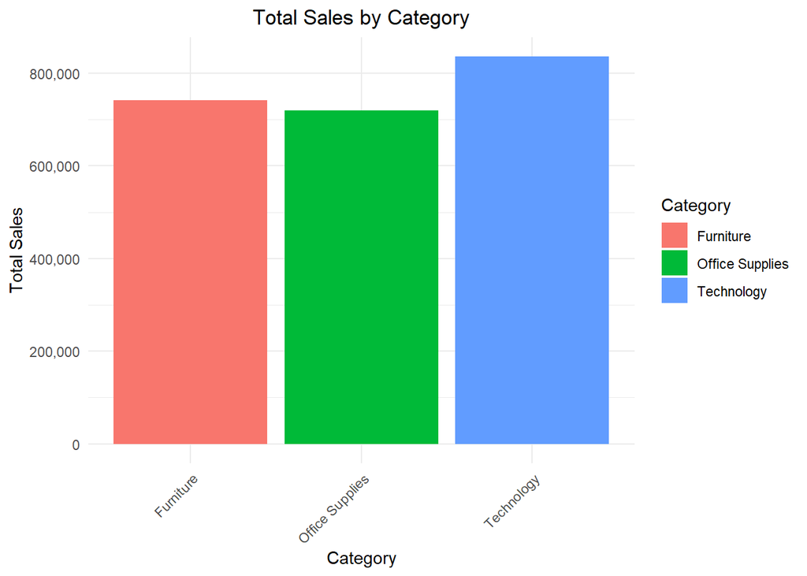

```r
#Bar plot
library(ggplot2)
library(scales)

ggplot(sales_by_category, aes(x = Category, y = Total_Sales, fill = Category)) +
  geom_bar(stat = "identity") +
  labs(title = "Total Sales by Category",
       x = "Category",
       y = "Total Sales") +
  theme_minimal() +
  theme(axis.text.x = element_text(angle = 45, hjust = 1),
        plot.title = element_text(hjust = 0.5)) +
  scale_y_continuous(labels = comma)
```

2. Create a scatter plot of Sales vs. Profit with a trend line.

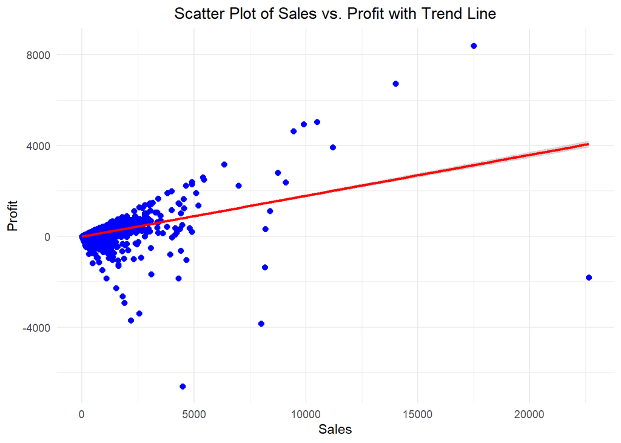

```r
ggplot(super_store, aes(x = Sales, y = Profit)) +
  geom_point(color = "blue", size = 2) +
  geom_smooth(method = "lm", color = "red", se = TRUE) +
  labs(title = "Scatter Plot of Sales vs. Profit with Trend Line",
       x = "Sales",
       y = "Profit") +
  theme_minimal() +
  theme(plot.title = element_text(hjust = 0.5))
```

3. Create a histogram of Profit_Margin.

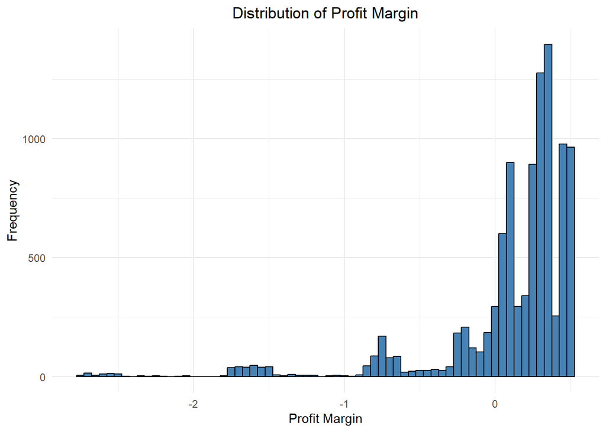

```r
#Histogram of Profit Margin

ggplot(data = super_store, aes(x = Profit_Margin)) +
  geom_histogram(binwidth = 0.05, fill = "steelblue", color = "black") +
  labs(title = "Distribution of Profit Margin",
       x = "Profit Margin",
       y = "Frequency") +
  theme_minimal()+
  theme(plot.title = element_text(hjust = 0.5))
```